# Understanding interactions

Andy Wills and Clare Walsh

# Contents

- Introduction
- Getting started
- Preprocessing
  - Filtering
  - Summarising
  - Pivot and mutate
- Density plot of differences
- Understanding interactions
  - Interaction as difference of differences
  - Factorial designs, main effects, and interactions
  - Exercise including line graphs

# Introduction

In the within-subject differences worksheet, we used a Bayesian within-subjects ANOVA to test for an effect of *word-picture congruence* in word naming. Specifically, we looked at an experiment in which people had to read words out loud as quickly as possible. On some trials, those words were accompanied by *congruent* pictures (e.g. the word ‘dog’ and a picture of a dog). On other trials, the words were accompanied by an *incongruent* picture (e.g. the word ‘dog’ and a picture of a pencil). Participants were instructed to ignore the pictures … but we found they could not do so. Reaction times were longer for *incongruent* trials than *congruent* trials, and there was substantial Bayesian evidence for that difference. In fact the Bayes Factor was over 40 million ($BF = 4.4 \times 10^{7}$).

These kinds of *congruency* effects are well known in psychology, and demonstrating them once again was not the main point of this experiment. Instead, the researchers were interested in the idea that learning how to meditate might increase your ability to attend to just the relevant aspects of a task. If this were true, the *congruency effect* would be smaller for those trained in meditation than for those who did not receive such training. In other words, the difference between the incongruent reaction time and the congruent reaction time would be smaller for meditators than non-meditators.

To test this idea, the experimenters randomly allocated 140 people to a week-long meditation training course, while another 140 people were randomly allocated to a no-training control condition. All these people then did a word-naming task. In this worksheet, and the next one, we’ll look at how to analyse data from this kind of experiment.

Specifically, our goal in these two worksheets is to work out the level of evidence for the hypothesis that meditation training reduces the size of the congruency effect. In order to do this, we need to make use of the concept of an *interaction*. This is a concept that for some people can take a while to grasp, so we’re going to take it in little steps, and approach it in a few different ways. By the end of these two worksheets, things should be clearer.

# Getting started

This worksheet uses the same *git* repository as the preprocessing and within-subject differences worksheets. Go back to your R project that contains this project now - you named it **your project**.

Open a new blank script, and save it as **anova2.R**. Enter all your commands into this script and run them from there. Save the script regularly.

The first step is to make sure you have loaded the data, and have loaded the R packages you need.

**Add the following comments and commands to your script and run them:**

```r
# Understanding interactions
# Load tidyverse
library(tidyverse)
# Load BayesFactor package
library(BayesFactor)
# Load data into 'words'
words <- read_csv("wordnaming2.csv")
```

Take a look back at the description of this data frame to remind yourself what it contains.

# Preprocessing

As before, we need to preprocess this large data set before we can analyse it.

## Filtering

In the full experiment, there were actually three between-subject conditions: meditation training, no training (“control”), and relaxation training. In this first example, we’re only going to look at the first two of those conditions: `meditate` and `control`. So, add this comment to your script:

```
# Filter out 'relax' condition; place remainder in 'MCwords'
```

and **add and run a command** that removes the participants in `relax` condition from the `words` data frame. It is the `medit` column of that data frame that contains the information about which condition each participant was in. Use the `filter` command to do this, and put the result into a new data frame called `MCwords`. As the `filter` command sets which data to *keep*, you may find the `!=` operator useful here – it means ‘not equal to’. If you need to revise how to do this, take a look back at the preprocessing worksheet.

*EXPECTED OUTPUT*: A new data frame called `MCwords` will be in your *Environment*. It will have 25,200 rows and 10 columns.

The full experiment also included three types of trial: congruent, incongruent, and neutral. The first two are described above. In *neutral* trials, the word is presented alone, without a picture. In this first example, we’re only going to look at the congruent and incongruent trials. So, add the following comment to your script:

```
# Filter out 'neutral' condition; place remainder in 'MCwordsCI'
```

and then **add and run a command** that removes the `neutral` trials from the `MCwords` data frame, and puts the filtered data into a new data frame called `MCwordsCI`. It is the `congru` column that contains information about trial type.

*EXPECTED OUTPUT*: A new data frame called `MCwordsCI` will be in your *Environment*. It will have 16,800 rows and 10 columns.

## Summarising

The data frame `MCwordsCI` is still very long, because it contains every trial for every participant. What we want to know, for each participant, is their mean reaction time on congruent and incongruent trials (i.e. two numbers per person). So, add the following comment to your script:

```
# Group by 'subj', 'congru' & 'medit'; calculate mean RT; place into 'MCwordsCIsum'
```

and then **add and run a command** to *group* the data by participant ID (`subj`), trial type (`congru`) and between-subjects condition (i.e. meditation versus control, `medit`). Get the mean reaction times using the `summarise` command, and put this summarised data into a new data frame called `MCwordsCIsum`. If you need a reminder of how to group and summarise data, take a look at the preprocessing worksheet. The column containing the RT data in this new data frame will need to have the name `rt`, because we assume this later on. You can set the column name within the `summarise` command. For example, `summarise(acc = mean(acc))` takes the mean of the column `acc` and puts the answer into a column called `acc` in your new data frame.

*EXPECTED OUTPUT*: A new data frame called `MCwordsCIsum` will be in your *Environment*. It will have 560 rows and 4 columns. There will be two rows for each participant, one for incongruent trials, one for congruent trials. Each participant will be identified as being in either the `meditate` or `control` condition.

## Pivoting and mutating

Exactly as we did in the within-subject differences worksheet, we can now use the `pivot_wider` and `mutate` commands to work out a *difference score* for each participant. This gives us the size of the *congruency effect* for that participant, i.e. how much more time they take on incongruent trials than congruent trials (on average).

**Enter the following comment and commands into your R script and run them**:

```r
# Pivot MCwordsCIsum into a wider data frame, calculate RT differences; results to 'medidiff'
medidiff <- MCwordsCIsum %>%
    pivot_wider(names_from = congru, values_from = rt) %>%
    mutate(diff = incong - cong)
```

Take a look at the `medidiff` data frame in your *Environment*. You’ll see there is now one row for each participant, with a difference score in the `diff` column. You may also notice that, in the `meditate` condition, there are about an equal number of positive and negative differences. Things look different in the `control` condition, where positive scores are much more likely than negative scores. So, on a quick look, it seems like the congruency effect might be (on average) smaller for those with meditation training.

# Density plot of differences

We can look at this difference in congruency effect more closely using a density plot. We make such a plot in the same way as we have on many previous occasions.

**Enter the following comment and commands into your R script and run them**:

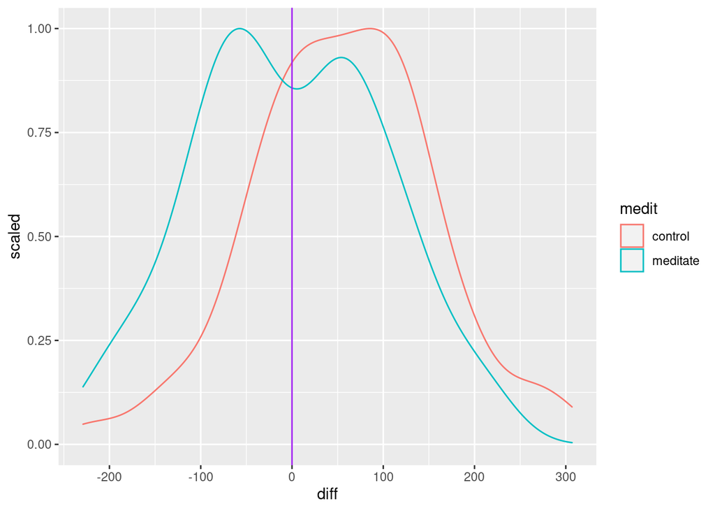

```r
# Display density plot of RT differences, by 'medit'
medidiff %>% ggplot(aes(diff, colour = medit)) +
    geom_density(aes(y = ..scaled..)) +
    geom_vline(xintercept = 0, colour = 'purple')
```

This plot is very much like the one we drew in the within-subject differences worksheet, and the curve for the control condition is identical. So, as before, we can see that in the control condition, most *congruency scores* are positive, although there is of course a range (from about -200 to +300 ms).

The new part of this graph is that we also have a curve for the meditation condition. It is the `colour=medit` part of the command that causes this to happen - it draws one curve for each *level* of the `medit` factor, and gives each a different colour.

We can see that the curve for the `meditate` condition is approximately centered on zero. In other words, on average, there is no congruency effect after meditation training.

# Understanding interactions

To summarise, we’ve found that the congruency effect is smaller after meditation training than after no training. The congruency effect is, as we have discussed, calculated as a difference between two average reaction times - the reaction time on incongruent trials minus the reaction time on congruent trials. This difference is smaller after meditation training than after no training. So, the results of this experiment can be described as a *difference of differences*. The RT difference is smaller for meditation than for control participants.

The phrase *difference of differences* is a bit clumsy, so we often use another, jargon, word for it. We say that the results of this experiment show an *interaction* between trial type (congruent, incongruent) and training type (meditation, control). This is just another way of saying the size of the difference between trial types is affected by training type. This is what our density plot of differences (above) shows.

## Factorial designs, main effects, and interactions

We normally talk about interactions in the context of experiments that have a *factorial* design. An experiment has a *factorial* design if more than one *factor* is manipulated, and all combinations of those factors are tested. For example, the meditation and attention experiment we’ve been looking at has a factorial design. It has two factors. The first factor is type of pre-training (meditation versus none). The second factor is type of test trial (congruent versus incongruent). The experiment has a *factorial* design because we have data for all four combinations of trial types (congruent, incongruent) and pre-training conditions (meditation, none).

With a two-factor experiment like this one, there are three basic analysis questions we can ask:

1. Averaging over different trial types (congruent, incongruent), does meditation affect reaction times? This is known as the **main effect** of meditation.
2. Averaging over different pre-training conditions (meditation, control), does trial type (congruent, incongruent) affect reaction times? This is known as the **main effect** of trial type (or the **main effect** of congruency, in this case).
3. Do these two main effects *interact*? So, for example, is the congruency effect smaller in the meditation condition than the control condition? This is known as the **interaction**.

For each of these questions, the answer can be either ‘yes’ or ‘no’. If we don’t have enough data, the answer could also be ‘we don’t know’, but we’ll come back to that later. So, when we analyse a two-factor experiment, there are eight different results we could get:

| Main effect 1: (e.g. meditation) | Main effect 2: (e.g. congruence) | Interaction |
| --- | --- | --- |
| no | no | no |
| no | no | yes |
| no | yes | no |
| no | yes | yes |
| yes | no | no |
| yes | no | yes |
| yes | yes | no |
| yes | yes | yes |

## Exercise

Below, you will find three graphs. Each shows four mean reaction times - mean reaction time for incongruent and congruent trials for both the meditation condition and the control condition. For each graph, decide whether there is a main effect of meditation, whether there is a main effect of congruence, and whether there is an interaction. **Write your answers into PsycEL in each case**.

### Graph 1

We’ll work through the first example together:

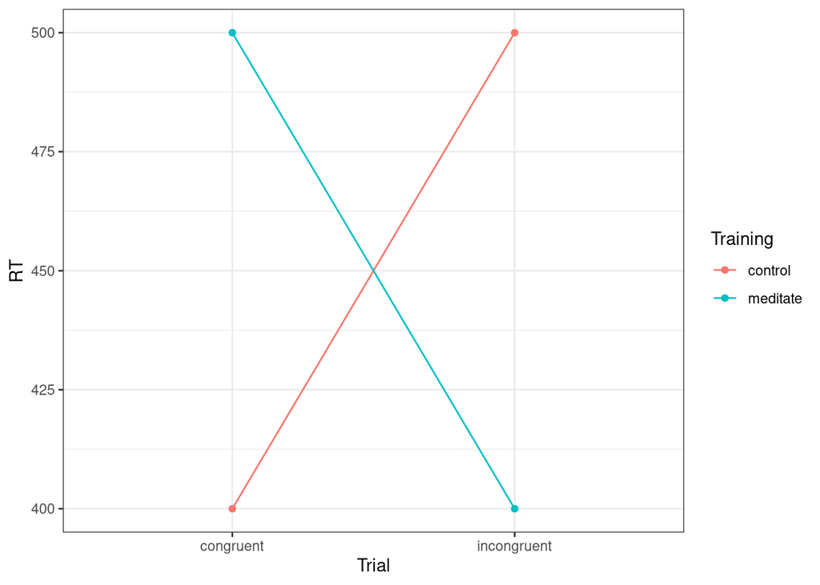

**Is there a main effect of trial type (congruence)?** No. There are two reaction times for the congruent trial type - 400ms (bottom left) and 500ms (top left). The average of these is 450 ms. Similarly, there are two reaction times for the incongruent trial type - 400 ms (bottom right) and 500 ms (top right). The average of these is also 450 ms. So, the average reaction time for congruent trials is the same as the average reaction time for incongruent trials, which means there is no main effect of trial type.

**Is there a main effect of training type (meditation)?** No. There are two reaction times for the control group - 400 ms (bottom left) and 500 ms (top right). The average is 450 ms. There are two reaction times for the meditate group - 500 ms (top left) and 400 ms (bottom right). The average is 450 ms. So, the average reaction time in the two groups is the same, so there is no main effect of training type.

**Is there an interaction?** Yes. Remember that an interaction is a difference of differences. In the control condition the incongruent RT is 500 ms and the congruent RT is 400 ms, so *incongruent - congruent = 100 ms*. In the meditate condition, the incongruent RT is 400 ms and the congruent RT is 500 ms, so *incongruent - congruent = - 100 ms*. These two differences are different (one is +100 ms, the other is -100 ms), so there is an interaction. Another way of easily spotting an interaction is if the lines on the graph are at different angles. In the graph above, the two lines have very different angles (one goes up from left to right, the other goes down). Unless the lines are parallel there is an interaction.

### Graph 2

Go through the same process to work out whether, in the graph below, there is a main effect of training, a main effect of trial type, and an interaction.

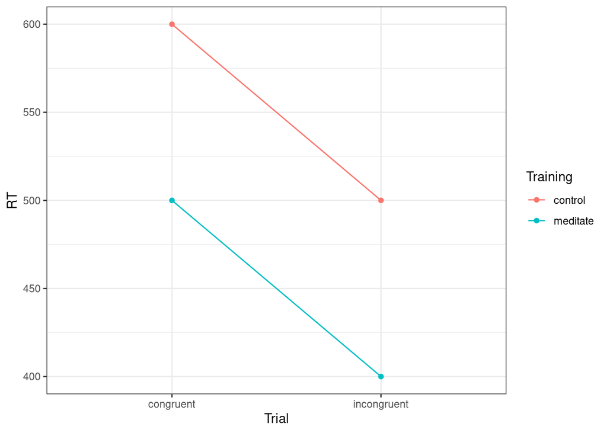

### Graph 3

Now do the same for this graph. At first glance, it might seem like there are only three data points on this graph. The congruent RT for the meditate group is identical to the congruent RT for the control group, and so only one point is visible.

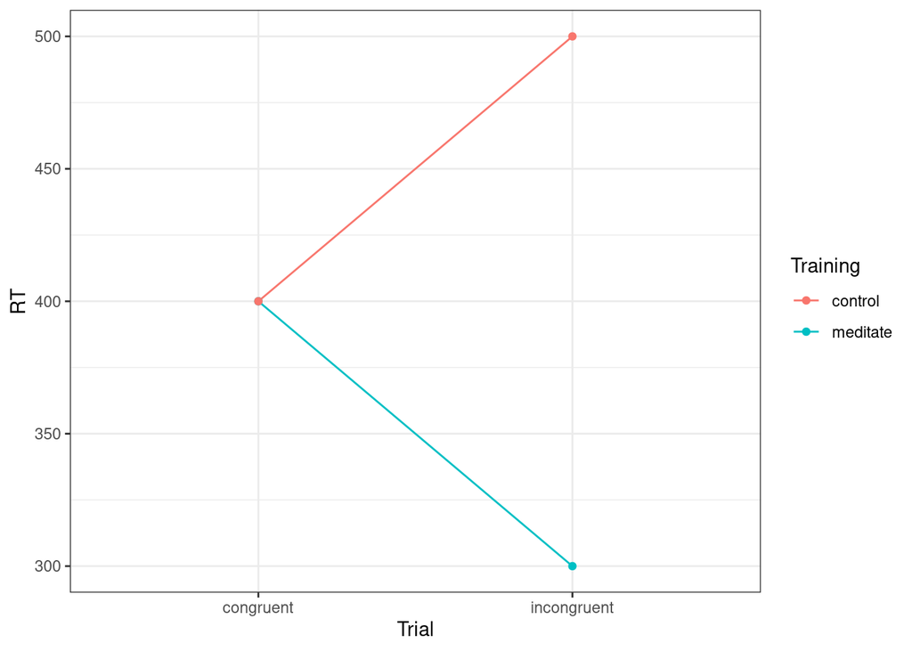

### Line graphs

In the next part of this exercise, we’ll use R to generate another graph of main effects and interactions. We haven’t done line graphs before, so first let’s have a look at how the three graphs above were produced.

#### Load the data

The data points for these graphs were loaded from a CSV file. There’s a copy of this file in the same *git* repository that we’ve being using throughout this worksheet, so the first thing to do is load it.

**Enter this comment and command into your R script and run it**:

```r
# Load data for interaction plot into 'interact'
interact <- read_csv("interact.csv")
```

Take a look at this data frame by clicking on it in your environment. You’ll find it has the following columns:

| Column | Description | Values |
| --- | --- | --- |
| Graph | ID number for the graph | 1-4 |
| Training | training condition | meditate, control |
| Trial | trial type | congruent, incongruent |
| RT | reaction time | a number |

Graphs 1 to 3 are the three shown above. There are no reaction times for Graph 4, because you’ll be adding those later.

#### Reproducing Graph 1

First, we’re going to reproduce Graph 1. The first step is to `filter` the data so it just includes the first graph.

**Enter this comment and command into your R script and run it**:

```r
# Select Graph 1 data, place in 'graph1'
graph1 <- interact %>% filter(Graph == 1)
```

Once that’s done, we can make a line graph, like this.

**Enter this comment and these commands into your R script and run them**:

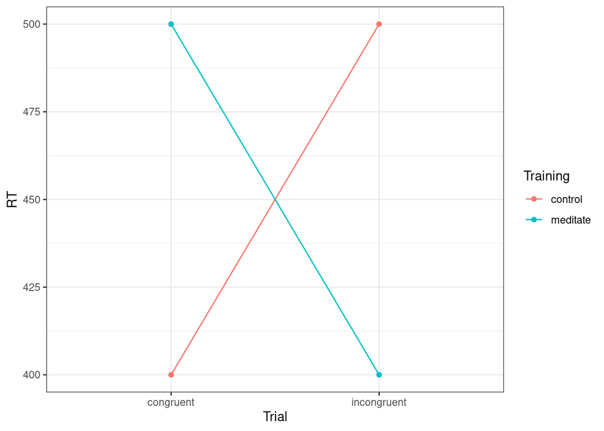

```r
# Display line graph, with Trial on x-axis; RT on y-axis, and 'Training' as a group
graph1 %>%
    ggplot(aes(x = Trial, y = RT, group = Training)) +
    geom_line(aes(colour = Training)) +
    geom_point(aes(colour = Training)) +
    theme_bw()
```

#### Explanation of command

This works in much the same way as the density plots you have made before:

`graph1 %>%` - Send the filtered data to the `ggplot` command that follows.

`ggplot()` - the command in R used to plot graphs.

`aes(x = Trial, y = RT, group = Training)` - This tells ggplot that you want trial type (`Trial`) on the x axis of your graph, and reaction time (`RT`) on the y axis. It also tells ggplot you want two lines, one for each of the training conditions (`group = Training`)

`geom_line()` - You want this to be a line graph

`aes(colour=Training)` - You want a different colour line for the two training conditions.

`geom_point()` - You also want points (plot symbols) on the lines, one for each data point.

`aes(colour=Training)` - You want the plot points to be different colours for the two training conditions.

`theme_bw()` - You want the graph background to be white rather than grey.

### Graph 4

Now you know how to produce line plots, the final part of this exercise is to produce a plot in which there is an interaction, a main effect of trial type, and **no** main effect of training type.

Download `interact.csv` to your local computer. Use a spreadsheet application to add in the missing reaction times for Graph 4, and upload it to RStudio.

If you need instructions on how to do this, see these worksheets on downloading and uploading. If you’re having trouble finding files within Rstudio, make sure you are looking in the *Files* tab, and make sure you are in the correct *folder*. The folder you are currently in is listed just to the right of the little picture of a house. You should be looking in `Home > your project`.

Next, reload `interact.csv` using `read_csv` and use a modified version of the code above to produce the graph. Include your code, along with appropriate comments, in your script.

Finally, **export your graph, download it to your local machine, and upload it to PsycEL**. If you need a reminder of how to do this, see downloading.

This material is distributed under a [Creative Commons](https://creativecommons.org/) licence. CC-BY-SA 4.0.